# STA 141A Final Project

### F. Sensitivity Analysis

Below are the results of my visual check to determine using residuals vs. fitted value plots whether the error terms in my models had constant variance, an assumption of my models. It appears that none of the graphs below (two for each country in the order of Spain, Belgium, United States, and Mexico, respectively, for their new cases and new deaths) have constant random scatter with many having distinct patterns in their scatter. This indicates that my assumptions of constant variance in the error terms and a linear relationships are incorrect, and if I had more time I would modify my model to take this information into account. For example, I may have include a quadratic term to rectify a time dependent relation that appears to be non-linear based on the quatratic curvature in many of the graphs.

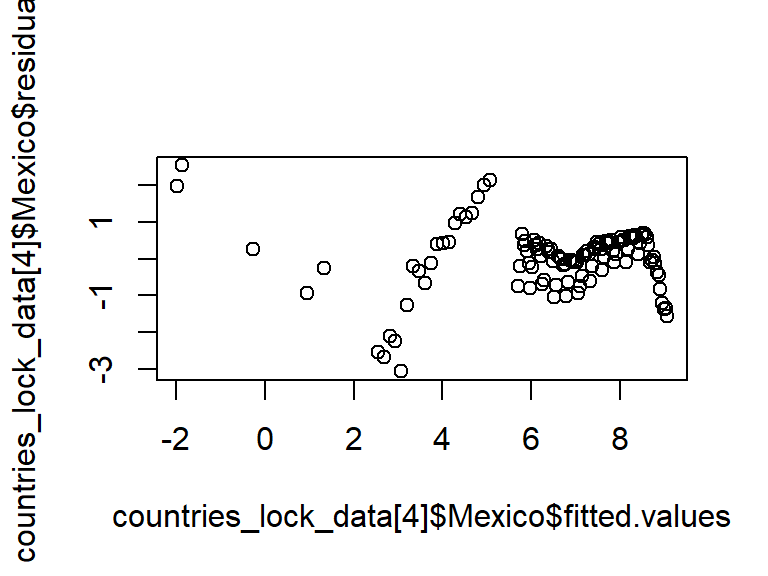

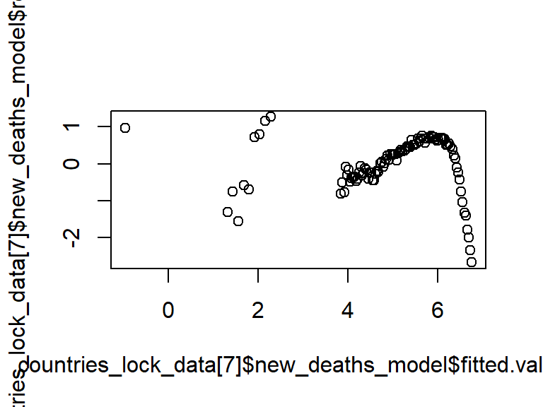

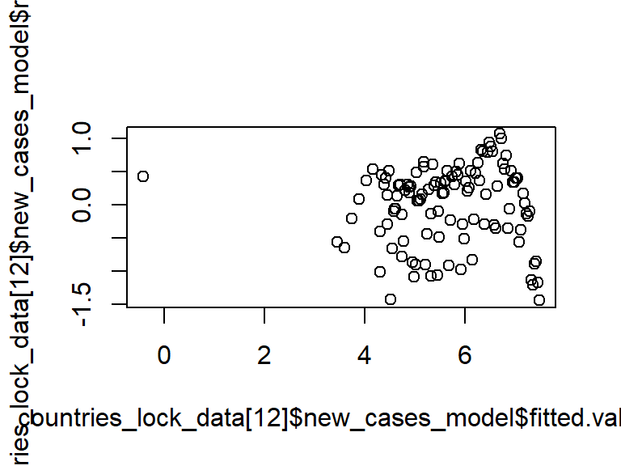

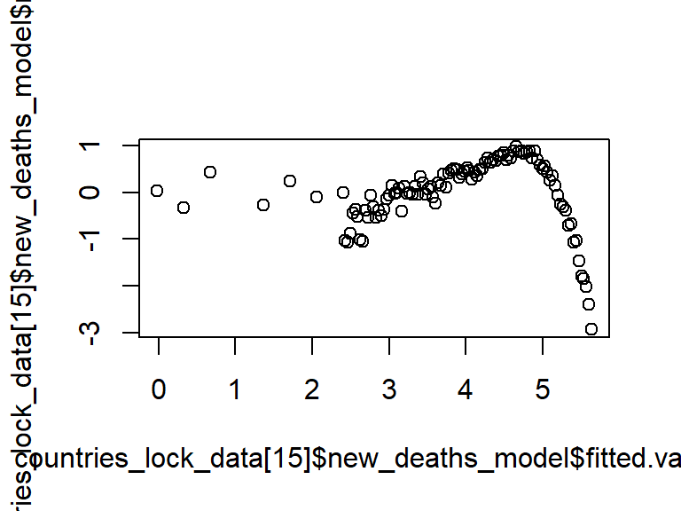

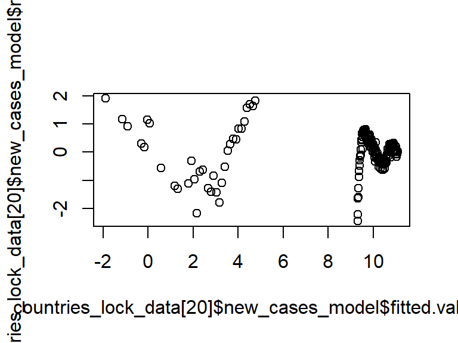

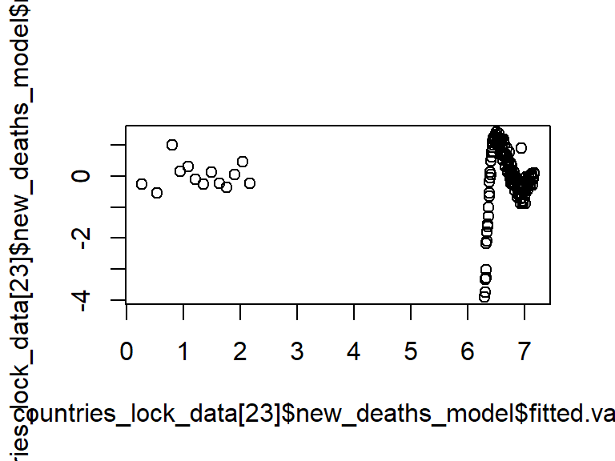

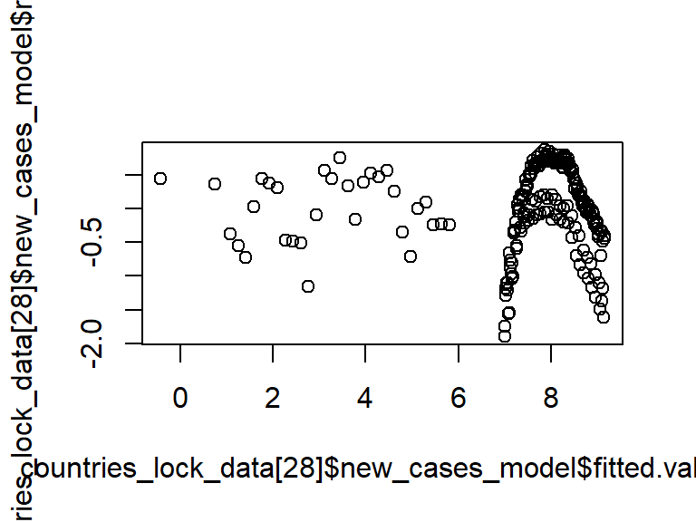

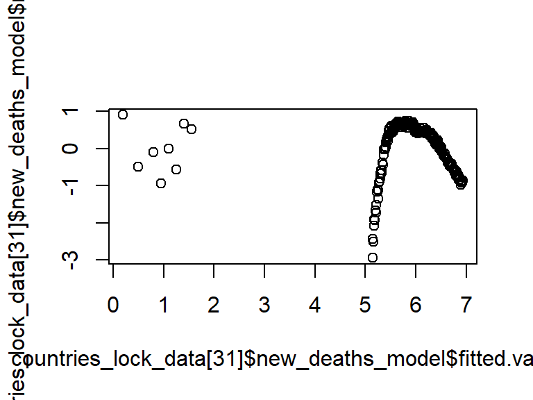

### G. Discussion

Using country-level data on the COVID-19 virus from the World Health Organization, I created a ordinary least squares regression model with an interrupted time series design to determine whether there was a significant correlation between the lockdown interventions and the reductions in virus spread and mortality. Unfortunately, during the sensitivity analysis it was discovered using residuals vs. fitted model plots that the assumptions of linearity and constant variance in the error terms were unlikely to be true. I had thought I sufficiently corrected for this by taking a log transformation of the data, but next time I will try a box-cox transformation and/or include non-linear model terms to improve upon my model in the future.

Some sources of error in my analysis include the criteria and frequency of virus testing and reporting and the extent to which the group that compiled the data of country-level virus intervention policy dates and levels had reasonable criteria for when a country was considered at level “2” restrictions. For instance, I noticed several discrepancies between the data visualization on the Our World in Data interactive graphic and the actual dataset, leading me to believe one or the other has multiple errors within it.

### H. Code Appendix

```r
### D. Descriptive Statistics

## Load libraries

library(formatR)
library(knitr)
library(tidyverse)
library(gridExtra)
library(scales)
library(lubridate)
library(ggplot2)
library(plotly)
library(sf)
library(jtools)
library(ggpubr)
library(dplyr)
library(dotwhisker)
library(openxlsx)
library(huxtable)
library(officer)
library(flextable)
library(ggfortify)
library(nlme)
library(car)
library(ggplot2)
library(tidyquant)
library(purrr)


## Code output formatting

knitr::opts_chunk$set(
    #error = FALSE,
    #message = FALSE,
    #warning = FALSE,
    echo = FALSE,
    fig.width=4, fig.height=3, #set figure size
    fig.align='center' #center plot
    #options(knitr.kable.NA = ''), #do not print NA in knitr table
    #tidy = FALSE #add line breaks in R codes
)


## Set functions

settingData = function (dataset, lockdown.date){

  dataset$time<-1:nrow(dataset)

  dataset$level<-NA
  dataset$level[dataset$date<lockdown.date]<-0
  dataset$level[dataset$date>=lockdown.date]<-1

  dataset$trend<-NA
  dataset$trend[dataset$date<lockdown.date]<-0
  dataset$trend[dataset$date>=lockdown.date]<-seq(1:sum(dataset$date>=lockdown.date))

  return(dataset)
}




 plotGraphicEpidemicCurves = function(dataset, local, lockdown.beg, lockdown.fin){

  g1<-ggplot(dataset)+
    #geom_rect(xmin=lockdown.beg, xmax=lockdown.fin, ymin=-Inf, ymax=Inf, fill="lightcyan1", alpha=1, inherit.aes = F)+
    geom_line(aes(x=date,y=totalCases, colour="Total cases"), size=2)+
    geom_line(aes(x=date,y=totalDeaths, colour="Total deaths"), size=2)+
    scale_colour_manual(values = c("blue", "red"))+
    scale_x_date(date_labels = "%b-%d", breaks = c(as.Date("2020-04-01"),as.Date("2020-05-01"),as.Date("2020-06-01")))+
    scale_y_continuous(labels = function(x) format(x, big.mark="."), limits = c(0,31000))+
    labs(title="Natural scale",
         x="",
         y = "")+
    guides(color=guide_legend(title=""))+
    theme_classic()+
    theme(plot.title = element_text(face = "italic", size = 18, hjust = 0.5),
          plot.subtitle = element_text(face = "italic", size = 12, hjust = 0.5),
          plot.caption = element_text(face = "italic", size = 12, hjust = 0.5),
          axis.title = element_text(face = "italic", size = 20, hjust = 0.5),
          axis.text = element_text(size = 18),
          legend.text=element_text(face = "italic", size = 16, hjust = 0.5),
          legend.title = element_text(size=14),
          legend.position = "bottom")
  g2<-ggplot(dataset)+
    #geom_rect(xmin=lockdown.beg, xmax=lockdown.fin, ymin=-Inf, ymax=Inf, fill="lightcyan1", alpha=1, inherit.aes = F)+
    geom_line(aes(x=date,y=log(totalCases), colour="Total cases"), size=2)+
    geom_line(aes(x=date,y=log(totalDeaths), colour="Total deaths"), size=2)+
    scale_colour_manual(values = c("blue", "red"))+
    scale_y_continuous(labels = function(x) format(x, big.mark="."), limits = c(0,10))+
    scale_x_date(date_labels = "%b-%d", breaks = c(as.Date("2020-04-01"),as.Date("2020-05-01"),as.Date("2020-06-01")))+
    labs(title="Logaritmic scale",
         x="",
         y = "")+
    guides(color=guide_legend(title=""))+
    theme_classic()+
    theme(plot.title = element_text(face = "italic", size = 18, hjust = 0.5),
          plot.subtitle = element_text(face = "italic", size = 12, hjust = 0.5),
          plot.caption = element_text(face = "italic", size = 12, hjust = 0.5),
          axis.title = element_text(face = "italic", size = 20, hjust = 0.5),
          axis.text = element_text(size = 18),
          legend.text=element_text(face = "italic", size = 16, hjust = 0.5),
          legend.title = element_text(size=14),
          legend.position = "bottom")
  annotate_figure(ggarrange(g1,g2, common.legend = T, legend = "bottom"),
                  top = text_grob(local, color = "black", face = "bold", size = 20))
}




plotGraphicNewCasesITS = function(dataset, local, lockdown.beg, lockdown.fin){

  m1<-lm(newCasesLog ~ time + level + trend,
         data=dataset)

  print(summary(m1))

  ggplot(dataset)+
    geom_rect(xmin=lockdown.beg, xmax=lockdown.fin, ymin=-Inf, ymax=Inf, fill="lightcyan1", alpha=1, inherit.aes = F)+
    geom_point(data = dataset%>%filter(level==0), aes(x=date, newCasesLog), size=2)+
    geom_point(data = dataset%>%filter(level==1), aes(x=date, newCasesLog), size=2)+
    scale_y_continuous(labels = function(x) format(x, big.mark="."))+
    scale_x_date(date_labels = "%b", breaks = c(as.Date("2020-04-01"),as.Date("2020-05-01"),as.Date("2020-06-01")))+
    geom_smooth(data=dataset%>%filter(level==0),
                aes(x=date, y=newCasesLog),
                method = "lm", formula = "y ~ x", se = T, colour="red", size=1.5)+
    geom_segment(data=dataset,
                 aes(x=date[1], y=m1$coefficients[1] + m1$coefficients[2],
                     xend=date[nrow(dataset)], yend=m1$coefficients[1] +  m1$coefficients[2]*nrow(dataset)),
                 colour="red", linetype="dashed", size=1.5)+
    geom_smooth(data=dataset%>%filter(level==1),
                aes(x=date, y=newCasesLog),
                method = "lm", formula = "y ~ x", se = T, colour="red", size=1.5)+
    labs(title=local,
         x="",
         y ="New daily cases (log)")+
    guides(color=guide_legend(title=""))+
    theme_classic()+
    theme(plot.title = element_text(face = "bold", size = 20, hjust = 0.5),
          plot.subtitle = element_text(face = "italic", size = 12, hjust = 0.5),
          plot.caption = element_text(face = "italic", size = 12, hjust = 0.5),
          axis.title = element_text(size = 12),
          axis.text = element_text(size = 20),
          legend.text=element_text(size=14),
          legend.title = element_text(size=14),
          legend.position = "none")
}




modelGeneral = function(dataset, variable){
  m1<-lm(variable~time + level + trend,
         data=dataset)

  return(m1)
}




modelSummary = function(dataset, variable){
  m1<-lm(variable~time + level + trend,
         data=dataset)

  return(summary(m1))
}




plotGraphicNewDeathsITS = function(dataset, local, lockdown.beg, lockdown.fin){
```

```r
  m1<-lm(newDeathsLog ~ time + level + trend,
         data=dataset)

  print(summary(m1))

  ggplot(dataset)+
    geom_rect(xmin=lockdown.beg, xmax=lockdown.fin, ymin=-Inf, ymax=Inf, fill="lightcyan1", alpha=1, inherit.aes = F)+
    geom_point(data = dataset%>%filter(level==0), aes(x=date, newDeathsLog), size=2)+
    geom_point(data = dataset%>%filter(level==1), aes(x=date, newDeathsLog), size=2)+
    scale_y_continuous(labels = function(x) format(x, big.mark="."))+
    scale_x_date(date_labels = "%b", breaks = c(as.Date("2020-04-01"),as.Date("2020-05-01"),as.Date("2020-06-01")))+
    geom_smooth(data=dataset%>%filter(level==0),
                aes(x=date, y=newDeathsLog),
                method = "lm", formula = "y ~ x", se = T, colour="red", size=1.5)+
    geom_segment(data=dataset,
                 aes(x=date[1], y=m1$coefficients[1] + m1$coefficients[2],
                     xend=date[nrow(dataset)], yend=m1$coefficients[1] +  m1$coefficients[2]*nrow(dataset)),
                 colour="red", linetype="dashed", size=1.5)+
    geom_smooth(data=dataset%>%filter(level==1),
                aes(x=date, y=newDeathsLog),
                method = "lm", formula = "y ~ x", se = T, colour="red", size=1.5)+
    labs(title=local,
         x="",
         y ="New daily deaths (log)")+
    guides(color=guide_legend(title=""))+
    theme_classic()+
    theme(plot.title = element_text(face = "bold", size = 20, hjust = 0.5),
          plot.subtitle = element_text(face = "italic", size = 12, hjust = 0.5),
          plot.caption = element_text(face = "italic", size = 12, hjust = 0.5),
          axis.title = element_text(size = 12),
          axis.text = element_text(size = 20),
          legend.text=element_text(size=14),
          legend.title = element_text(size=14),
          legend.position = "none")
}




plotGraphicModelsCasesITS = function(country_models){
  graph_cases <- list()
  for(i in 1:length(country_models)){
    graph_cases[[i]] <- local({
      i <- i
      g<-dwplot(purrr::map(country_models[[i]], "newCases"),
                dot_args = list(size = 2),
                line_args = list(alpha = 6, size = 1),
                vline = geom_vline(xintercept = 0, colour = "grey60", linetype = 2)) +
        theme_classic()+
        labs(title=names(country_models)[i],
             x="",
             y = "")+
        guides(color=guide_legend(title="Days post-intervetion", label.hjust = .5))+
        theme(legend.position = "bottom",
              legend.justification = c(0, 0),
              legend.background = element_rect(colour="grey80"),
              legend.title.align = .5,
              plot.title = element_text(face = "bold", size = 20, hjust = 0.5),
              plot.subtitle = element_text(face = "italic", size = 12, hjust = 0.5),
              plot.caption = element_text(face = "italic", size = 12, hjust = 0.5),
              axis.title = element_text(size = 12),
              axis.text = element_text(size = 22),
              legend.text=element_text(size=14),
              legend.title = element_text(size=14))
    })
  }
  return (graph_cases)
}

plotGraphicModelsDeathsITS = function(country_models){
  graph_deaths <- list()
  for(i in 1:length(country_models)){
    graph_deaths[[i]] <- local({
      i <- i
      g<-dwplot(purrr::map(country_models[[i]], "newDeaths"),
                dot_args = list(size = 2),
                line_args = list(alpha = 6, size = 1),
                vline = geom_vline(xintercept = 0, colour = "grey60", linetype = 2)) +
        theme_classic()+
        labs(title=names(country_models)[i],
             x="",
             y = "")+
        guides(color=guide_legend(title="Days post-intervetion", label.hjust = .5))+
        theme(legend.position = "bottom",
              legend.justification = c(0, 0),
              legend.background = element_rect(colour="grey80"),
              legend.title.align = .5,
              plot.title = element_text(face = "bold", size = 20, hjust = 0.5),
              plot.subtitle = element_text(face = "italic", size = 12, hjust = 0.5),
              plot.caption = element_text(face = "italic", size = 12, hjust = 0.5),
              axis.title = element_text(size = 12),
              axis.text = element_text(size = 22),
              legend.text=element_text(size=14),
              legend.title = element_text(size=14))
    })
  }
  return (graph_deaths)
}


## Data cleaning

# Load data into R

covid.data <- read_csv("WHO_Covid_Data.csv")


# Remove unnecessary row and column info

covid.data <- covid.data %>% filter(Country %in% c("United States of America","Mexico","Spain","Belgium")) %>% select(-WHO_region)


# Translate variable names to names used in functions
names(covid.data)<-c("date","country_code","country","newCases","totalCases","newDeaths","totalDeaths")


# Convert the time variable to Date class

covid.data$date <- as.Date(covid.data$date)


# Discover duration of lockdown for each country

lockdown.data <- read.csv("stay-at-home-covid.csv")
lockdown_US.data <- lockdown.data %>% filter(Entity == "United States",stay_home_requirements == 2)
lockdown_MX.data <- lockdown.data %>% filter(Entity == "Mexico",stay_home_requirements == 2)
lockdown_ES.data <- lockdown.data %>% filter(Entity == "Spain",stay_home_requirements == 2)
lockdown_BE.data <- lockdown.data %>% filter(Entity == "Belgium",stay_home_requirements == 2)


# Create lockdown info dataframe for analysis, "countries_lock_info"

countries_lock_info <- data.frame(country_code=c("ES","BE","US","MX"),
                    name=c("Spain","Belgium","United States","Mexico"),
                    lock_beg=c(as.Date("2020-03-14"),as.Date("2020-03-18"),as.Date("2020-03-15"),as.Date("2020-03-30")),
                    lock_fin=c(as.Date("2020-05-26"),as.Date("2020-06-07"),as.Date("2020-07-19"),as.Date("2020-09-10")),
                    stringsAsFactors = F)



# Summary statistics on each country for cumulative cases/cumulative deaths/death per case rate before lockdown,lockdown period,lockdown duration, cumulative cases/deaths at the end of the investigation period, time since beginning of pandemic that the investigation period started, range/variance/median of cases/deaths during investigation period
```

```r
table_before_lockdown_info <- data.frame(Cases_before_lockdown=c(4535,2142,2959,96193),Deaths_before_lockdown=c(105,33,60,6927), Case_mortality_rate_before_lockdown=c(105/4535,33/2142,60/2959,6927/96193),Time_since_pandemic_began=c("3 days","7 days","4 days","19 days"),row.names=c("Spain","Belgium","United States","Mexico"))


Spain_intervention_period <- covid.data %>% filter(country_code=="ES" & date>=countries_lock_info$lock_beg[1] &  date<=countries_lock_info$lock_fin[1]+14)

standard_deviation_daily_cases_Spain <- sd(Spain_intervention_period$newCases)

Spain_intervention_period_new_cases_info <- summary(Spain_intervention_period$newCases)

standard_deviation_daily_deaths_Spain <- sd(Spain_intervention_period$newDeaths)

Spain_intervention_period_new_deaths_info <- summary(Spain_intervention_period$newDeaths)


Belgium_intervention_period <- covid.data %>% filter(country_code=="BE" & date>=countries_lock_info$lock_beg[2] &  date<=countries_lock_info$lock_fin[2]+14)

standard_deviation_daily_cases_Belgium <- sd(Belgium_intervention_period$newCases)

Belgium_intervention_period_new_cases_info <- summary(Belgium_intervention_period$newCases)

standard_deviation_daily_deaths_Belgium <- sd(Belgium_intervention_period$newDeaths)

Belgium_intervention_period_new_deaths_info <- summary(Belgium_intervention_period$newDeaths)


United_States_intervention_period <- covid.data %>% filter(country_code=="US" & date>=countries_lock_info$lock_beg[3] &  date<=countries_lock_info$lock_fin[3]+14)

standard_deviation_daily_cases_United_States <- sd(United_States_intervention_period$newCases)

United_States_intervention_period_new_cases_info <- summary(United_States_intervention_period$newCases)

standard_deviation_daily_deaths_United_States <- sd(United_States_intervention_period$newDeaths)

United_States_intervention_period_new_deaths_info <- summary(United_States_intervention_period$newDeaths)


Mexico_intervention_period <- covid.data %>% filter(country_code=="MX" & date>=countries_lock_info$lock_beg[4] &  date<=countries_lock_info$lock_fin[4]+14)

standard_deviation_daily_cases_Mexico <- sd(Mexico_intervention_period$newCases)

Mexico_intervention_period_new_cases_info <- summary(Mexico_intervention_period$newCases)

standard_deviation_daily_deaths_Mexico <- sd(Mexico_intervention_period$newDeaths)

Mexico_intervention_period_new_deaths_info <- summary(Mexico_intervention_period$newDeaths)


table_intervention_info <- data.frame(Lockdown_period=c("March 14 to May 26","March 18 to June 7","March 15 to July 19","March 30 to September 10"),Lockdown_duration=c("74 days","82 days","127 days","165 days"), Range_daily_cases=c("143 to 10,136 cases","22 to 2,336.0 cases","951 to 76,791 cases","166 to 9,133 cases"), Standard_deviation_daily_cases=c("2701.9 cases","579.03 cases","18,076 cases","2535.4 cases"),Median_daily_cases=c("1694.5","432.0","27,030","4,132"), Range_daily_deaths=c("21 to 913 deaths","4 to 324 deaths","11 to 2699 deaths","9 to 840 deaths"),Standard_deviation_daily_deaths=c("291.46 deaths","93.065 deaths","663.99 deaths","224.84 deaths"), Median_daily_deaths=c("212.50 deaths","70.5 deaths","965 deaths","575 deaths"), row.names=c("Spain","Belgium","United States","Mexico"))


Spain_covid_period <- covid.data %>% filter(country_code=="ES" & date<=countries_lock_info$lock_fin[1]+14)

Belgium_covid_period <- covid.data %>% filter(country_code=="BE" & date<=countries_lock_info$lock_fin[2]+14)

United_States_covid_period <- covid.data %>% filter(country_code=="US" & date<=countries_lock_info$lock_fin[3]+14)

Mexico_covid_period <- covid.data %>% filter(country_code=="MX" & date<=countries_lock_info$lock_fin[4]+14)

covid_period <- covid.data %>% filter(date<=countries_lock_info$lock_fin[4]+14)


table_before_lockdown_info
table_intervention_info


# Exploratory Visualizations

new_cases_all_countries <- covid_period %>% ggplot(aes(x=date,y=newCases,color=country))+
  geom_line()+
  labs(title="New Cases for All Countries")+
  xlab("Date")+
  scale_y_continuous(name="New Cases",breaks=(c(seq(from=0,to=77000,by=4000))),limits = (c(0,77000)))


new_deaths_all_countries <- covid_period %>% ggplot(aes(x=date,y=newDeaths,color=country))+
  geom_line()+
  labs(title="New Deaths for All Countries")+
  xlab("Date")+
  scale_y_continuous(name="New Deaths",breaks=(c(seq(from=0,to=2800,by=200))),limits = (c(0,2800)))


new_cases_Belgium <- Belgium_covid_period %>% ggplot(aes(x=date,y=newCases))+
  geom_line()+
  labs(title="New Cases for Belgium")+
  xlab("Date")+
  scale_y_continuous(name="New Cases",breaks=(c(seq(from=0,to=2400,by=200))),limits = (c(0,2400)))+
  geom_vline(xintercept=countries_lock_info$lock_beg[2],linetype=3)


new_cases_Mexico <- Mexico_covid_period %>% ggplot(aes(x=date,y=newCases))+
  geom_line()+
  labs(title="New Cases for Mexico")+
  xlab("Date")+
  scale_y_continuous(name="New Cases",breaks=(c(seq(from=0,to=9200,by=1000))),limits = (c(0,9200)))+
  geom_vline(xintercept=countries_lock_info$lock_beg[4],linetype=3)


  Spain_covid_period$newCasesLog <- log(Spain_covid_period$newCases)
  Spain_covid_period$newCasesLog[is.infinite(Spain_covid_period$newCasesLog)] <- NA

  Spain_covid_period$newDeathsLog <- log(Spain_covid_period$newDeaths)
  Spain_covid_period$newDeathsLog[is.infinite(Spain_covid_period$newDeathsLog)] <- NA


  Belgium_covid_period$newCasesLog <- log(Belgium_covid_period$newCases)
  Belgium_covid_period$newCasesLog[is.infinite(Belgium_covid_period$newCasesLog)] <- NA

  Belgium_covid_period$newDeathsLog <- log(Belgium_covid_period$newDeaths)
  Belgium_covid_period$newDeathsLog[is.infinite(Belgium_covid_period$newDeathsLog)] <- NA


  United_States_covid_period$newCasesLog <- log(United_States_covid_period$newCases)
  United_States_covid_period$newCasesLog[is.infinite(United_States_covid_period$newCasesLog)] <- NA

  United_States_covid_period$newDeathsLog <- log(United_States_covid_period$newDeaths)
  United_States_covid_period$newDeathsLog[is.infinite(United_States_covid_period$newDeathsLog)] <- NA
```

```r
  Mexico_covid_period$newCasesLog <- log(Mexico_covid_period$newCases)
  Mexico_covid_period$newCasesLog[is.infinite(Mexico_covid_period$newCasesLog)] <- NA

  Mexico_covid_period$newDeathsLog <- log(Mexico_covid_period$newDeaths)
  Mexico_covid_period$newDeathsLog[is.infinite(Mexico_covid_period$newDeathsLog)] <- NA


  log_new_cases_Spain <- Spain_covid_period %>% ggplot(aes(x=date,y=newCasesLog))+
  geom_point()+
  labs(title="Log Transformation New Cases for Spain")+
  xlab("Date")+
  scale_y_continuous(name="Log Transformation New Cases")+
  geom_vline(xintercept=countries_lock_info$lock_beg[1],linetype=3)

  log_new_deaths_Spain <- Spain_covid_period %>% ggplot(aes(x=date,y=newDeathsLog))+
  geom_point()+
  labs(title="Log Transformation New Deaths for Spain")+
  xlab("Date")+
  scale_y_continuous(name="Log Transformation New Deaths")+
  geom_vline(xintercept=countries_lock_info$lock_beg[1],linetype=3)


  log_new_cases_Belgium <- Belgium_covid_period %>% ggplot(aes(x=date,y=newCasesLog))+
  geom_point()+
  labs(title="Log Transformation New Cases for Belgium")+
  xlab("Date")+
  scale_y_continuous(name="Log Transformation New Cases")+
  geom_vline(xintercept=countries_lock_info$lock_beg[2],linetype=3)

  log_new_deaths_Belgium <- Belgium_covid_period %>% ggplot(aes(x=date,y=newDeathsLog))+
  geom_point()+
  labs(title="Log Transformation New Deaths for Belgium")+
  xlab("Date")+
  scale_y_continuous(name="Log Transformation New Deaths")+
  geom_vline(xintercept=countries_lock_info$lock_beg[2],linetype=3)


  log_new_cases_United_States <- United_States_covid_period %>% ggplot(aes(x=date,y=newCasesLog))+
  geom_point()+
  labs(title="Log Transformation New Cases for the US")+
  xlab("Date")+
  scale_y_continuous(name="Log Transformation New Cases")+
  geom_vline(xintercept=countries_lock_info$lock_beg[3],linetype=3)

  log_new_deaths_United_States <- United_States_covid_period %>% ggplot(aes(x=date,y=newDeathsLog))+
  geom_point()+
  labs(title="Log Transformation New Deaths for the US")+
  xlab("Date")+
  scale_y_continuous(name="Log Transformation New Deaths")+
  geom_vline(xintercept=countries_lock_info$lock_beg[3],linetype=3)


  log_new_cases_Mexico <- Mexico_covid_period %>% ggplot(aes(x=date,y=newCasesLog))+
  geom_point()+
  labs(title="Log Transformation New Cases for Mexico")+
  xlab("Date")+
  scale_y_continuous(name="Log Transformation New Cases")+
  geom_vline(xintercept=countries_lock_info$lock_beg[4],linetype=3)

  log_new_deaths_Mexico <- Mexico_covid_period %>% ggplot(aes(x=date,y=newDeathsLog))+
  geom_point()+
  labs(title="Log Transformation New Deaths for Mexico")+
  xlab("Date")+
  scale_y_continuous(name="Log Transformation New Deaths")+
  geom_vline(xintercept=countries_lock_info$lock_beg[4],linetype=3)




new_cases_all_countries

new_deaths_all_countries

new_cases_Belgium

new_cases_Mexico
log_new_cases_Spain
log_new_deaths_Spain
log_new_cases_Belgium
log_new_deaths_Belgium
log_new_cases_United_States
log_new_deaths_United_States
log_new_cases_Mexico
log_new_deaths_Mexico


  # "for" loop for compiling info for each country into "countries_lock_data"

countries_lock_data <- list()
for(i in 1:nrow(countries_lock_info)){

  # Select the country according to the country code, subset dates up to 14 days after a lockdown ends

  country <- covid.data %>% filter(country_code==countries_lock_info$country_code[i]
                                   & date<=countries_lock_info$lock_fin[i]+14)


  # Add variables "newCasesLog" (log transformation of new cases data) and "newDeathsLog" (log transformation of "newDeaths" data) to the "country" dataset for modeling later

  country$newCasesLog <- log(country$newCases)
  country$newCasesLog[is.infinite(country$newCasesLog)] <- NA #For days with zero new cases

  country$newDeathsLog <- log(country$newDeaths)
  country$newDeathsLog[is.infinite(country$newDeathsLog)] <- NA #For days with zero new deaths


  # Add variables "time" (indicating the day a set of observations occurred where "1" is the first day a set of observations occurred), "level" (indicating whether an observation occurred before lockdown began "0" or during/after lockdown "1"), and "trend" (indicating the number of days the lockdown has been in effect when an observation occurred) to the "country" dataset for modeling later

  country <- settingData(country,countries_lock_info$lock_beg[i])


  # Produce natural scale graphs and logarithmic scale graphs for cumulative cases over time and cumulative deaths over time

  gCountryCurves <- plotGraphicEpidemicCurves(country,countries_lock_info$name[i],countries_lock_info$lock_beg[i], countries_lock_info$lock_fin[i])


  # Produce the graphs of the interrupted time series models for log transformation of new cases and produce model statistics

  gCountryNewCasesITS<-plotGraphicNewCasesITS(country,countries_lock_info$name[i],
                       countries_lock_info$lock_beg[i], countries_lock_info$lock_fin[i])
  mGenNewCasesITS<-modelGeneral(country,country$newCasesLog)
  mSumNewCasesITS<-modelSummary(country,country$newCasesLog)


  # Produce the graphs of the interrupted time series models for log transformation of new deaths and produce model statistics

  gCountryNewDeathsITS<-plotGraphicNewDeathsITS(country,countries_lock_info$name[i],
                        countries_lock_info$lock_beg[i], countries_lock_info$lock_fin[i])
  mGenNewDeathsITS<-modelGeneral(country,country$newDeathsLog)
  mSumNewdeathsITS<-modelSummary(country,country$newDeathsLog)


  #Compile info for each country into "countries_lock_data"

  country_data <- list(
                  data=country,
                  epidemic_graphs=gCountryCurves,
                  new_cases_graph_its=gCountryNewCasesITS,
                  new_cases_model=mGenNewCasesITS,
                  new_cases_model_summary=mSumNewCasesITS,
                  new_deaths_graph_its=gCountryNewDeathsITS,
                  new_deaths_model=mGenNewDeathsITS,
                  new_deaths_model_summary=mSumNewdeathsITS
                  )
  countries_lock_data <- append(countries_lock_data, country_data)
  names(countries_lock_data)[i] <- countries_lock_info$name[i]
}
```

```r
### E. Inferential Analysis

# Graphs for New daily cases for the countries

countries_lock_data[3]

countries_lock_data[11]

countries_lock_data[19]

countries_lock_data[27]


# Graphs for New daily deaths for the countries

countries_lock_data[6]

countries_lock_data[14]

countries_lock_data[22]

countries_lock_data[30]


# Table 2: Models and coefficients for New daily cases for the countries

# countries_lock_data[5]
#
# countries_lock_data[13]
#
# countries_lock_data[21]
#
# countries_lock_data[29]

Model_parameters_newCases <- data.frame(
                            Spain=c("-4.3826 (***) (0.7170)","0.13316 (***) (0.01256)",
                          "4.0272 (***) (0.3300)","-0.17165 (***) (0.01312)","0.8628"),
                          Belgium=c("-5.1622 (***) (1.0285)","0.14357 (***) (0.01555)",
                          "1.9175 (***) (0.2402)","-0.17699 (***) (0.01571)","0.7984"),
                    United_States=c("-4.1257 (***) (0.4364)","0.12357 (***) (0.00807)",
                          "4.5225 (***) (0.2321)","-0.11075 (***) (0.00820)","0.9577"),
                           Mexico=c("-8.8911 (***) (0.8700)","0.16895 (***) (0.01202)",
                          "1.1815 (***) (0.2357)","-0.15678 (***) (0.01206)","0.9037"),
                        row.names=c("Intercept","Time","Level","Trend","R_Squared")
                                        )

Model_parameters_newCases


# Table 3: Models and coefficients for New daily deaths for the countries

# countries_lock_data[8]
#
# countries_lock_data[16]
#
# countries_lock_data[24]
#
# countries_lock_data[32]

Model_parameters_newDeaths <- data.frame(
                             Spain=c("-6.2497 (**) (2.1145)","0.12017 (***) (0.03247)",
                            "4.5101 (***) (0.3529)","-0.15360 (***) (0.03263)","0.7896"),
                           Belgium=c("-23.617 (**) (8.342)","0.3469  (**)  (0.1165)",
                            "3.2718 (***) (0.5141)","-0.3808 (**) (0.1165)","0.7161"),
                     United_States=c("-7.6505 (.) (4.2847)","0.13648 (*) (0.06502)",
                            "4.1149 (***) (0.51233)","-0.13025 (*) (0.06505)","0.7211"),
                            Mexico=c("-11.70050 (>0.1) (7.49161)","0.15240 (.) (0.09007)",
                          "3.57045 (***) (0.44662)","-0.14230 (>0.1) (0.09008)","0.7196"),
                         row.names=c("Intercept","Time","Level","Trend","R_Squared")
                                        )

Model_parameters_newDeaths


#Generating confidence intervals for B_3

country_models<-list()
for(i in 1:nrow(countries_lock_info)){
  models<-list()
  for(k in 15:21){
    country<-covid.data%>%filter(country_code==countries_lock_info$country_code[i] & date<=countries_lock_info$lock_fin[i]+k)
    country<-settingData(country,countries_lock_info$lock_beg[i])

    logNewCases<-log(country$newCases)
    logNewCases[is.infinite(logNewCases)]<-NA
    mNewcasesITS<-modelGeneral(country,logNewCases)

    logNewDeaths<-log(country$newDeaths)
    logNewDeaths[is.infinite(logNewDeaths)]<-NA
    mNewdeathsITS<-modelGeneral(country,logNewDeaths)


    model<-list(newCases=mNewcasesITS,newDeaths=mNewdeathsITS)
    models<-append(models, list(model))
  }
  names(models)<-paste(rep(15:21), "days")
  country_models<-append(country_models, list(models))
  names(country_models)[i]<-countries_lock_info$name[i]
}

graph_cases <- plotGraphicModelsCasesITS(country_models)
graph_deaths <- plotGraphicModelsDeathsITS(country_models)


  #Confidence intervals for parameters for new cases for each day one week after lockdown ends for each country

graph_cases[1]

graph_cases[2]

graph_cases[3]

graph_cases[4]

  #Confidence intervals for parameters for new deaths for each day one week after lockdown ends for each country

graph_deaths[1]

graph_deaths[2]

graph_deaths[3]

graph_deaths[4]


### F. Sensitivity Analysis

# Testing assumption of the error term having constant variance



#Spain residuals vs. fitted values plot

plot(countries_lock_data[4]$Mexico$fitted.values,countries_lock_data[4]$Mexico$residuals)

plot(countries_lock_data[7]$new_deaths_model$fitted.values,countries_lock_data[7]$new_deaths_model$residuals)


#Belgium residuals vs. fitted values plot

plot(countries_lock_data[12]$new_cases_model$fitted.values,countries_lock_data[12]$new_cases_model$residuals)

plot(countries_lock_data[15]$new_deaths_model$fitted.values,countries_lock_data[15]$new_deaths_model$residuals)


#United States residuals vs. fitted values plot

plot(countries_lock_data[20]$new_cases_model$fitted.values,countries_lock_data[20]$new_cases_model$residuals)

plot(countries_lock_data[23]$new_deaths_model$fitted.values,countries_lock_data[23]$new_deaths_model$residuals)


#Mexico residuals vs. fitted values plot

plot(countries_lock_data[28]$new_cases_model$fitted.values,countries_lock_data[28]$new_cases_model$residuals)

plot(countries_lock_data[31]$new_deaths_model$fitted.values,countries_lock_data[31]$new_deaths_model$residuals)
sessionInfo()
```

### I. Acknowledgement

The idea for the project and much of the code used for the analysis is from the article “The effect of lockdown on the COVID-19 epidemic in Brazil: evidence from an interrupted time series design” by Lucas Silva, Dalson Figueiredo Filho, and Antônio Fernandes. I owe them a debt of gratitude for providing such an accessible analysis of COVID-19 data.

### J. References

[1] World Heath Organization

Link to WHO website where data is found: https://covid19.who.int/info

Link to data: https://covid19.who.int/WHO-COVID-19-global-data.csv

[2] Our World in Data

Link to website where data is found (go to the “Download” tab that is part of the interactive map): https://ourworldindata.org/covid-stay-home-restrictions

[3] WHO information on 14 day incubation period:

World Health Organization. “Considerations for quarantine of individuals in the context of containment for coronavirus disease (COVID-19).” Geneva: World Health Organization; 2020.